# Diabetes Prediction

### Predicting Diabetes Status (Positive or Negative) in Patients Based on their Medical and Demographic History by Building Machine Learning Models

##### PSTAT130 Spring 2023

## **Introduction**

The aim of this project is to build a machine learning model capable of predicting whether a patient may be at risk of developing diabetes. To accomplish this, I will utilize a [diabetes dataset](https://www.kaggle.com/datasets/iammustafatz/diabetes-prediction-dataset) gathered from Electronic Health Records (EHRs), digital versions of patients' health records. These records contain a wealth of information about patients' medical history, diagnoses, treatments, and outcomes. Throughout this project, I will implement multiple machine learning techniques to generate the most accurate model for this binary classification problem.

### Motivation and Expectation

According to Diabetes Research Institute Foundation.), approximately 37.3 million Americans, or about 11.3% of the U.S. population, have diabetes as of 2022. Alarmingly, it's estimated that roughly 20%, or around 8.5 million of these individuals, have not yet been diagnosed. Furthermore, the number of patients diagnosed with diabetes is increasing rapidly each year. This alarming trend underscores the urgent need for early detection and intervention strategies, thus highlighting the importance and potential impact of our diabetes prediction project. Our dataset contains vital information, including age, gender, body mass index (BMI), hypertension, heart disease, smoking history, HbA1c level, and blood glucose level. By analyzing these factors, we can explore the relationships between medical and demographic characteristics and the likelihood of developing diabetes. This prediction project enables us to create personalized treatment plans for patients, aiming to improve outcomes and enhance patient satisfaction.

### Roadmap of the Project

Now that we have a better understanding of the importance of our model, let's discuss our plan to successfully build it in this project. Firstly, we will ensure the quality of our dataset by performing additional checks for any duplications or missing observations. We will also review the predictor variables and eliminate any that are unnecessary or overly complex by either removing or combining them. Secondly, with our clean dataset, we will conduct further exploratory analysis to uncover correlations between predictors. This will provide us with a deeper understanding of the factors that contribute to the likelihood of developing diabetes. Thirdly, we will proceed with the implementation of a training/test split and cross-validation on our data. We plan to utilize models such as Logistic Regression, Decision Tree, Random Forest, and K-Nearest Neighbors to train our data and make predictions. Lastly, once we have obtained accuracy results from each model, we will compare their performances and select the one or two models that perform best. We will then fit the chosen model(s) to our testing dataset to thoroughly analyze its effectiveness in predicting diabetes. Let's begin!

## **Exploratory Data Analysis**

First, we will mount the Google Drive and load our dataset. After that, we need to examine the data to identify necessary adjustments. During this process, we will remove unnecessary or missing data if any exist. We will also convert some variables into factors and combine or create sub-predictors to decrease the complexity of our dataset. Furthermore, we will analyze our cleaned data using visualization tools and other functions to gain a deeper understanding of each predictor's correlation.

```python
# mount google drive
from google.colab import drive
drive.mount('/content/drive')
```

```python
# No warning message
import warnings
warnings.filterwarnings('ignore')

# import neccessary libraries
import pandas as pd
import numpy as np
import seaborn as sns
import matplotlib.pyplot as plt

from sklearn.model_selection import train_test_split, cross_val_score # train and test split and cross-validation
from sklearn.model_selection import GridSearchCV # Parameter tuning
from sklearn.preprocessing import LabelEncoder # encoding

from sklearn.linear_model import LogisticRegression # Logistic Regression Model
from sklearn.tree import DecisionTreeClassifier # Classification Decision Tree Model
from sklearn.ensemble import RandomForestClassifier # Classification Random Forest Model
from sklearn.neighbors import KNeighborsClassifier #K-Nearest Neighbors

from sklearn.metrics import accuracy_score, classification_report, confusion_matrix # prediction matrix
```

```python
# lading dataset
df = pd.read_csv('/content/drive/MyDrive/Colab Notebooks/Diabetes_Classification/diabetes_prediction_dataset.csv')
```

```python
df.info()
```

```
<class 'pandas.core.frame.DataFrame'>
RangeIndex: 100000 entries, 0 to 99999
Data columns (total 9 columns):
 #   Column               Non-Null Count   Dtype
---  ------               --------------   -----
 0   gender               100000 non-null  object
 1   age                  100000 non-null  float64
 2   hypertension         100000 non-null  int64
 3   heart_disease        100000 non-null  int64
 4   smoking_history      100000 non-null  object
 5   bmi                  100000 non-null  float64
 6   HbA1c_level          100000 non-null  float64
 7   blood_glucose_level  100000 non-null  int64
 8   diabetes             100000 non-null  int64
dtypes: float64(3), int64(4), object(2)
memory usage: 6.9+ MB
```

```python
df.shape
```

```
(100000, 9)
```

- Total number of entries in the DataFrame: 100,000
- Number of columns: 9, 'gender' (object), 'age' (float64), 'hypertension' (int64), 'heart_disease' (int64), 'smoking_history' (object), 'bmi' (float64), 'HbA1c_level' (float64), 'blood_glucose_level' (int64), 'diabetes' (int64)
- All columns have non-null values.
- Data types of the columns are available also.

```python
# checking null values
print(df.isnull().sum())
```

```
gender                 0
age                    0
hypertension           0
heart_disease          0
smoking_history        0
bmi                    0
HbA1c_level            0
blood_glucose_level    0
diabetes               0
dtype: int64
```

No missing value

Before we dive into the details of Explanatory Data Analysis, where we closely examine the data, it is important to ensure that our dataset only contains rows with unique values. In other words, we do not want any duplicate values as they are unnecessary.

Let's check for any duplicate values in our dataset.

```python
# checking any duplicate values
duplicate_rows = df.duplicated()

if duplicate_rows.any():
    print("Duplicate rows exist in the dataset.")
else:
    print("No duplicate rows found in the dataset.")

duplicate_rows = df[df.duplicated()]
print("Number of duplicate rows:", duplicate_rows.shape[0])

print(duplicate_rows)
```

```
Duplicate rows exist in the dataset.
Number of duplicate rows: 3854
       gender   age  hypertension  heart_disease smoking_history    bmi  \
2756     Male  80.0             0              0         No Info  27.32
3272   Female  80.0             0              0         No Info  27.32
3418   Female  19.0             0              0         No Info  27.32
3939   Female  78.0             1              0          former  27.32
3960     Male  47.0             0              0         No Info  27.32
...       ...   ...           ...            ...             ...    ...
99980  Female  52.0             0              0           never  27.32
99985    Male  25.0             0              0         No Info  27.32
99989  Female  26.0             0              0         No Info  27.32
99990    Male  39.0             0              0         No Info  27.32
99995  Female  80.0             0              0         No Info  27.32

       HbA1c_level  blood_glucose_level  diabetes
2756           6.6                  159         0
3272           3.5                   80         0
3418           6.5                  100         0
3939           3.5                  130         0
3960           6.0                  200         0
...            ...                  ...       ...
99980          6.1                  145         0
99985          5.8                  145         0
99989          5.0                  158         0
99990          6.1                  100         0
99995          6.2                   90         0

[3854 rows x 9 columns]
```

It appears that there are 3,854 duplicated values in the dataset.

```python
print(df.iloc[99995])
```

```
gender                  Female
age                       80.0
hypertension                 0
heart_disease                0
smoking_history        No Info
bmi                      27.32
HbA1c_level                6.2
blood_glucose_level         90
diabetes                     0
Name: 99995, dtype: object
```

```python
for index, row in df.iterrows():
    if (row['gender'] == "Female" and
        row['age'] == 80.0 and
        row['hypertension'] == 0 and
        row['heart_disease'] == 0 and
        row['smoking_history'] == "No Info" and
        row['bmi'] == 27.32 and
        row['HbA1c_level'] == 6.2 and
        row['blood_glucose_level'] == 90 and
        row['diabetes'] == 0):
        print("Index:", index)
```

```
Index: 51020
Index: 60900
Index: 63116
Index: 70329
Index: 74359
Index: 75291
Index: 89647
Index: 98457
Index: 99995
```

There are 8 rows in the dataset that have the same values as row 99995.

```python
# dropping dulplicates
df = df.drop_duplicates()
```

Now, our dataset contains only rows with unique values.

```python
for index, row in df.iterrows():
    if (row['gender'] == "Female" and
        row['age'] == 80.0 and
        row['hypertension'] == 0 and
        row['heart_disease'] == 0 and
        row['smoking_history'] == "No Info" and
        row['bmi'] == 27.32 and
        row['HbA1c_level'] == 6.2 and
        row['blood_glucose_level'] == 90 and
        row['diabetes'] == 0):
        print("Index:", index)


# Checking for duplicated values
duplicated_count = df.duplicated().sum()
print("Number of duplicated values:", duplicated_count)
```

```
Index: 51020
Number of duplicated values: 0
```

Now, we only have one row that contains the above values, which means there are no more duplicated values in the dataset.

Let's check our dataset again.

```python
# checking the dataset information
df.info()
```

```
<class 'pandas.core.frame.DataFrame'>
Int64Index: 96146 entries, 0 to 99999
Data columns (total 9 columns):
 #   Column               Non-Null Count  Dtype
---  ------               --------------  -----
 0   gender               96146 non-null  object
 1   age                  96146 non-null  float64
 2   hypertension         96146 non-null  int64
 3   heart_disease        96146 non-null  int64
 4   smoking_history      96146 non-null  object
 5   bmi                  96146 non-null  float64
 6   HbA1c_level          96146 non-null  float64
 7   blood_glucose_level  96146 non-null  int64
 8   diabetes             96146 non-null  int64
dtypes: float64(3), int64(4), object(2)
memory usage: 7.3+ MB
```

```python
# checking the number of columns and rows
df.shape
```

```
(96146, 9)
```

Without any duplicated values, our dataset contains 96,146 rows and 9 columns.

```python
# various distribution of the numerical data
df.describe()
```

|  | age | hypertension | heart_disease | bmi | HbA1c_level | blood_glucose_level | diabetes |
| --- | --- | --- | --- | --- | --- | --- | --- |
| count | 96146.000000 | 96146.000000 | 96146.000000 | 96146.000000 | 96146.000000 | 96146.000000 | 96146.000000 |
| mean | 41.794326 | 0.077601 | 0.040803 | 27.321461 | 5.532609 | 138.218231 | 0.088220 |
| std | 22.462948 | 0.267544 | 0.197833 | 6.767716 | 1.073232 | 40.909771 | 0.283616 |
| min | 0.080000 | 0.000000 | 0.000000 | 10.010000 | 3.500000 | 80.000000 | 0.000000 |
| 25% | 24.000000 | 0.000000 | 0.000000 | 23.400000 | 4.800000 | 100.000000 | 0.000000 |
| 50% | 43.000000 | 0.000000 | 0.000000 | 27.320000 | 5.800000 | 140.000000 | 0.000000 |
| 75% | 59.000000 | 0.000000 | 0.000000 | 29.860000 | 6.200000 | 159.000000 | 0.000000 |
| max | 80.000000 | 1.000000 | 1.000000 | 95.690000 | 9.000000 | 300.000000 | 1.000000 |

```python
df.head()
```

|  | gender | age | hypertension | heart_disease | smoking_history | bmi | HbA1c_level | blood_glucose_level | diabetes |
| --- | --- | --- | --- | --- | --- | --- | --- | --- | --- |
| 0 | Female | 80.0 | 0 | 1 | never | 25.19 | 6.6 | 140 | 0 |
| 1 | Female | 54.0 | 0 | 0 | No Info | 27.32 | 6.6 | 80 | 0 |
| 2 | Male | 28.0 | 0 | 0 | never | 27.32 | 5.7 | 158 | 0 |
| 3 | Female | 36.0 | 0 | 0 | current | 23.45 | 5.0 | 155 | 0 |
| 4 | Male | 76.0 | 1 | 1 | current | 20.14 | 4.8 | 155 | 0 |

```python
df.tail()
```

|  | gender | age | hypertension | heart_disease | smoking_history | bmi | HbA1c_level | blood_glucose_level | diabetes |
| --- | --- | --- | --- | --- | --- | --- | --- | --- | --- |
| 99994 | Female | 36.0 | 0 | 0 | No Info | 24.60 | 4.8 | 145 | 0 |
| 99996 | Female | 2.0 | 0 | 0 | No Info | 17.37 | 6.5 | 100 | 0 |
| 99997 | Male | 66.0 | 0 | 0 | former | 27.83 | 5.7 | 155 | 0 |
| 99998 | Female | 24.0 | 0 | 0 | never | 35.42 | 4.0 | 100 | 0 |
| 99999 | Female | 57.0 | 0 | 0 | current | 22.43 | 6.6 | 90 | 0 |

```python
# returning the unique values in the 'gender' column
df['gender'].unique()
```

```
array(['Female', 'Male', 'Other'], dtype=object)
```

```python
# providing a count of each unique value in the 'gender' column
df['gender'].value_counts()
```

```
Female    56161
Male      39967
Other        18
Name: gender, dtype: int64
```

Considering the counts provided for the 'gender' category, where 'Other' has only 18 occurrences compared to a significantly larger number of occurrences for 'Female' and 'Male', it may be reasonable to contemplate removing the 'Other' category from the 'gender' predictor.

```python
# Exclude rows with 'Other' as gender
df = df[df['gender'] != 'Other']

df.shape
```

```
(96128, 9)
```

Now, our dataset contains 96,128 rows and 9 columns.

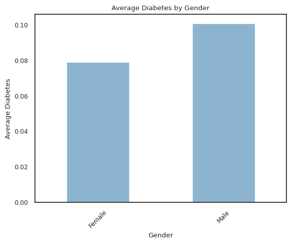

```python
# bar plot shows the average diabetes occurrence across gender
df.groupby('gender').mean()['diabetes'].plot(kind = 'bar',rot = 45)
plt.xlabel('Gender')
plt.ylabel('Average Diabetes')
plt.title('Average Diabetes by Gender')
plt.show()
```

The average number of diabetes cases is higher among males compared to females.

```python
# returning the unique values in the 'smoking_history' column
df['smoking_history'].unique()
```

```
array(['never', 'No Info', 'current', 'former', 'ever', 'not current'],
      dtype=object)
```

```python
# providing a count of each unique value in the 'smoking_history' column
df['smoking_history'].value_counts()
```

```
never          34395
No Info        32881
former          9299
current         9197
not current     6359
ever            3997
Name: smoking_history, dtype: int64
```

To reclassify the 'smoking_history' column, we can group the values into three distinct categories: non-smokers, smokers, and individuals with unknown smoking history. We can accomplish this by assigning the following labels: "never" to represent non-smokers, "no info" to represent unknown smoking history, and a collective label of "former, current, not current, ever" to represent smokers. This categorization simplifies the scale, making it easier to differentiate between individuals who have never smoked, those who have smoked at some point, and those for whom the smoking history is unknown.

```python
# non-smokers, smokers, and individuals with unknown smoking history

def recategorize_smoking_history(smoking_status):
    if smoking_status == 'never':
        return 'non_smokers'
    elif smoking_status in ['former', 'current', 'not current', 'ever']:
        return 'smokers'
    elif smoking_status == 'No Info':
        return 'unknown_smoking_history'

# Apply the function to the 'smoking_history' column
df['smoking_history'] = df['smoking_history'].apply(recategorize_smoking_history)

# Check the new value counts
print(df['smoking_history'].value_counts())
```

```
non_smokers                34395
unknown_smoking_history    32881
smokers                    28852
Name: smoking_history, dtype: int64
```

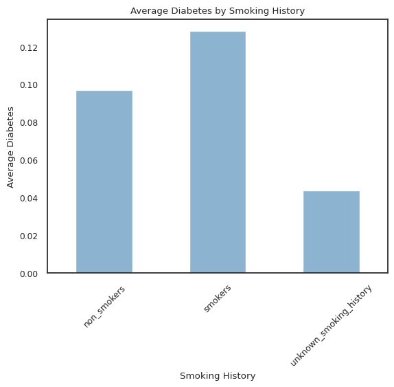

```python
# bar plot shows the average diabetes occurrence across smoking history categories
df.groupby('smoking_history').mean()['diabetes'].plot(kind='bar', rot=45)
plt.xlabel('Smoking History')
plt.ylabel('Average Diabetes')
plt.title('Average Diabetes by Smoking History')
plt.show()
```

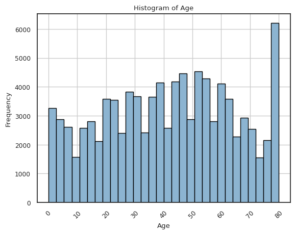

```python
# histogram of age displays the frequency distribution of ages in the dataset
df['age'].plot(kind = 'hist', bins = 30, grid = True, rot = 45, edgecolor='black')
plt.xlabel('Age')
plt.ylabel('Frequency')
plt.title('Histogram of Age')
plt.show()
```

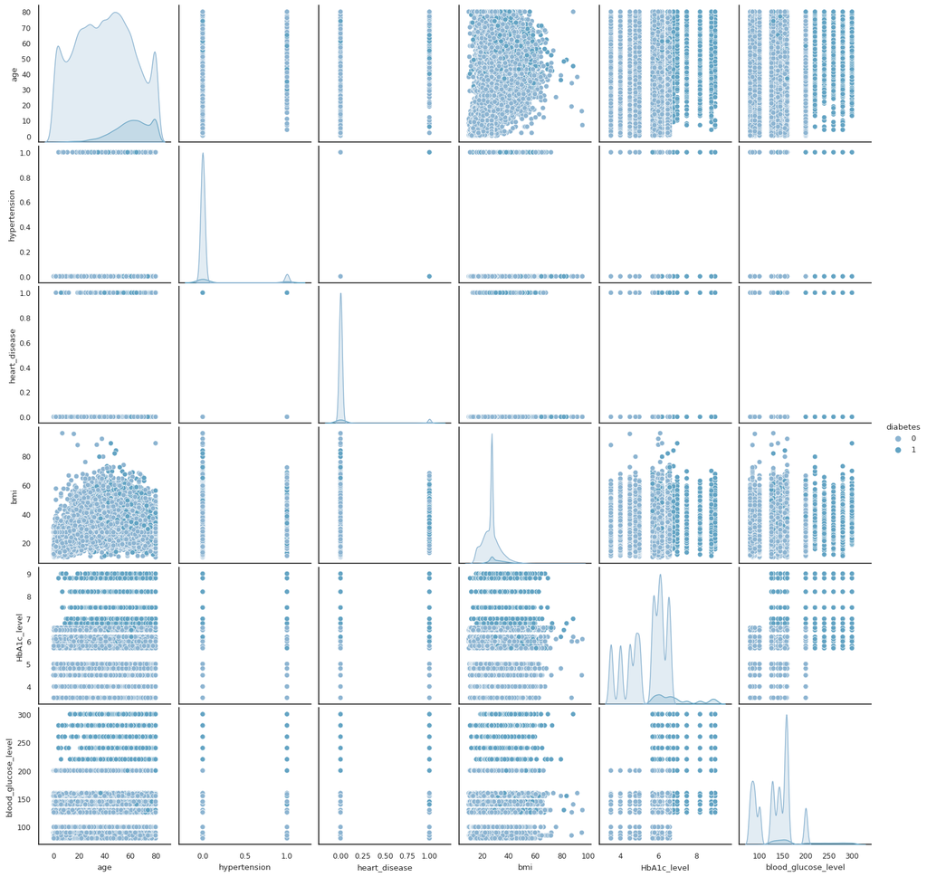

```python
# # Pair plot for numeric features
sns.pairplot(df, hue='diabetes')
plt.show()
```

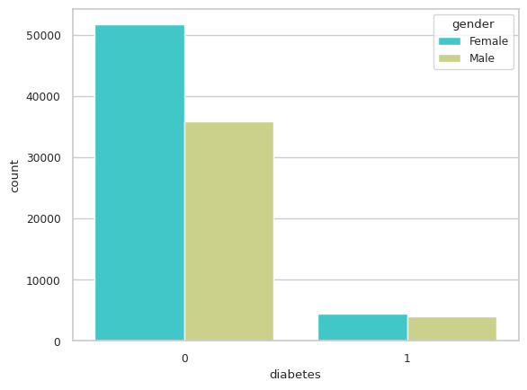

```python
sns.set_style('whitegrid')
sns.countplot(x = 'diabetes', hue = 'gender', data = df, palette = 'rainbow')
```

Among individuals without diabetes, the number of females is higher.

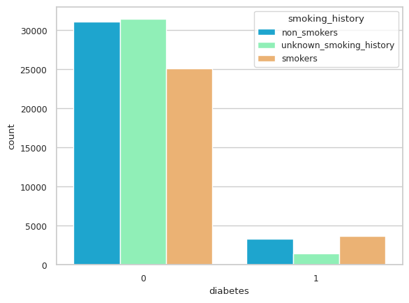

```python
sns.set_style('whitegrid')
sns.countplot(x = 'diabetes', hue = 'smoking_history', data = df, palette = 'rainbow')
```

Among individuals without diabetes, the number of smokers is the lowest, while it appears that smokers have the highest representation among those with diabetes.

```python
# counting number of each value in 'HbA1c_level'
df['HbA1c_level'].value_counts()
```

```
6.6    8161
5.7    8123
6.5    8051
5.8    7992
6.0    7987
6.2    7956
6.1    7712
3.5    7316
4.8    7296
4.5    7289
4.0    7204
5.0    7153
8.8     660
8.2     659
9.0     652
7.5     642
6.8     642
7.0     633
Name: HbA1c_level, dtype: int64
```

```python
# counting number of each value in 'blood_glucose_level'
df['blood_glucose_level'].value_counts()
```

```
159    7475
130    7471
126    7419
140    7414
160    7393
145    7371
200    7289
155    7285
90     6820
80     6785
100    6774
158    6737
85     6631
280     724
300     673
260     634
240     633
220     600
Name: blood_glucose_level, dtype: int64
```

```python
# categorical features (X_cat), numerical features (X_num), and target variable 'diabetes'
X_cat = df.drop(['age', 'bmi', 'diabetes'], axis=1)
X_num = df[['age', 'bmi']]
y = df['diabetes']

# encoding the categorical columns in X_cat using LabelEncoder.
le = LabelEncoder()
for col in X_cat.columns:
  X_cat[col] = le.fit_transform(X_cat[col])

# categorical features (X_cat) and numerical features (X_num) together in X
X = pd.concat([X_num, X_cat], axis=1)
```

```python
X
```

|  | age | bmi | gender | hypertension | heart_disease | smoking_history | HbA1c_level | blood_glucose_level |
| --- | --- | --- | --- | --- | --- | --- | --- | --- |
| 0 | 80.0 | 25.19 | 0 | 0 | 1 | 0 | 11 | 6 |
| 1 | 54.0 | 27.32 | 0 | 0 | 0 | 2 | 11 | 0 |
| 2 | 28.0 | 27.32 | 1 | 0 | 0 | 0 | 5 | 9 |
| 3 | 36.0 | 23.45 | 0 | 0 | 0 | 1 | 4 | 8 |
| 4 | 76.0 | 20.14 | 1 | 1 | 1 | 1 | 3 | 8 |
| ... | ... | ... | ... | ... | ... | ... | ... | ... |
| 99994 | 36.0 | 24.60 | 0 | 0 | 0 | 2 | 3 | 7 |
| 99996 | 2.0 | 17.37 | 0 | 0 | 0 | 2 | 10 | 3 |
| 99997 | 66.0 | 27.83 | 1 | 0 | 0 | 1 | 5 | 8 |
| 99998 | 24.0 | 35.42 | 0 | 0 | 0 | 0 | 1 | 3 |
| 99999 | 57.0 | 22.43 | 0 | 0 | 0 | 1 | 11 | 2 |

96128 rows × 8 columns

```python
y
```

```
0        0
1        0
2        0
3        0
4        0
        ..
99994    0
99996    0
99997    0
99998    0
99999    0
Name: diabetes, Length: 96128, dtype: int64
```

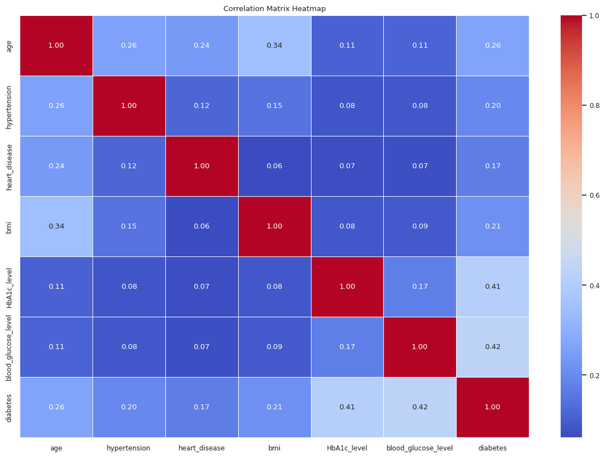

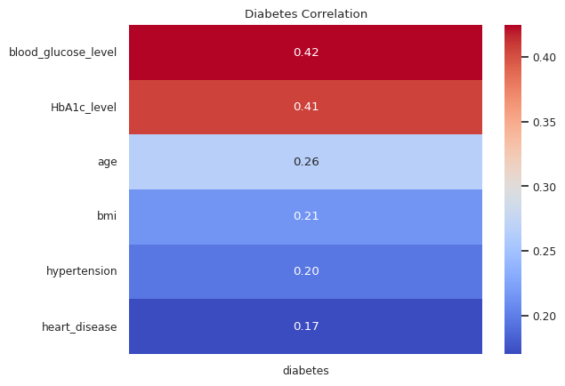

```python
# Computing the correlation matrix
correlation_matrix = df.corr()

# graph one
plt.figure(figsize=(15, 10))
sns.heatmap(correlation_matrix, annot=True, cmap='coolwarm', linewidths=0.5, fmt='.2f')
plt.title("Correlation Matrix Heatmap")
plt.show()

# graph two
# creating a heatmap of the correlations with the target column
corr = df.corr()
target_corr = corr['diabetes'].drop('diabetes')

sns.set(font_scale=0.8)
sns.set_style("white")
sns.set_palette("PuBuGn_d")
target_corr_sorted = target_corr.sort_values(ascending=False)
sns.heatmap(target_corr_sorted.to_frame(), cmap="coolwarm", annot=True, fmt='.2f')
plt.title('Diabetes Correlation')
plt.show()
```

The feature 'blood_glucose_level' exhibits the highest correlation with diabetes, while 'heart_disease' demonstrates the lowest correlation with diabetes.

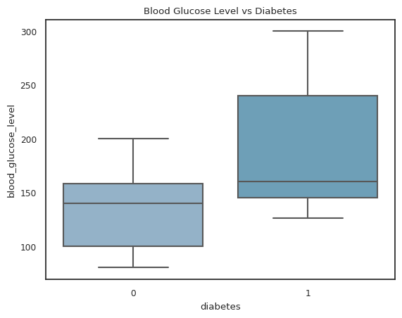

```python
# Boxplot blood glucose level vs Diabetes
sns.boxplot(x='diabetes', y='blood_glucose_level', data=df)
plt.title('Blood Glucose Level vs Diabetes')
plt.show()
```

Individuals with diabetes exhibit a wider range of 'blood_glucose_level'.

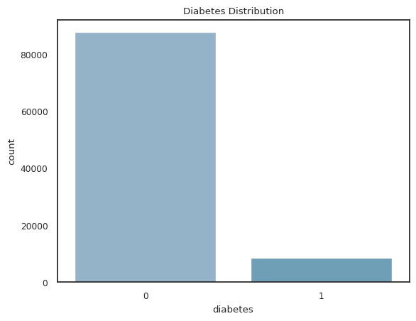

```python
# count plot for the 'diabetes' variable
sns.countplot(x='diabetes', data=df)
plt.title('Diabetes Distribution')
plt.show()
```

```python
df['diabetes'].value_counts(normalize = True) *100
```

```
0    91.176348
1     8.823652
Name: diabetes, dtype: float64
```

There are 8.82% positive cases and 91.17% negative cases for diabetes, indicating a significant class imbalance in the data. To address this, we will conduct one process using the train and test split approach and another process using the Synthetic Minority Over-sampling Technique (SMOTE). This will ensure that our data and model are balanced, reducing the risk of bias.

Let's first save our cleaned data into CSV and Excel files.

```python
# saving a cleaned data
cleaned_data = pd.concat([X, y], axis=1)

cleaned_data.to_csv('clean_data.csv', index=False)
cleaned_data.to_excel('clean_data.xlsx', index=False)
```

```python
# data split into training and testing
X_train, X_test, y_train, y_test = train_test_split(X, y, test_size=0.3, random_state=30, stratify=y)
```

```python
X_train.shape
```

```
(67289, 8)
```

```python
y_train.value_counts(normalize = True) *100
```

```
0    91.176864
1     8.823136
Name: diabetes, dtype: float64
```

```python
y_test.value_counts(normalize = True) *100
```

```
0    91.175145
1     8.824855
Name: diabetes, dtype: float64
```

Both the y_train and y_test datasets exhibit the same ratio of diabetes cases.

## Building Models

```python
# cross validation on LogisticRegression
model_lr = LogisticRegression(max_iter = 2000)
cv = cross_val_score(model_lr,X_train,y_train,cv=5)
print(cv)
print(cv.mean())
```

```
[0.9503641  0.9461287  0.95073562 0.9490266  0.95117783]
0.9494865682542081
```

```python
# cross validation on DecisionTreeClassifier
model_dt = DecisionTreeClassifier(random_state = 1)
cv = cross_val_score(model_dt,X_train,y_train,cv=5)
print(cv)
print(cv.mean())
```

```
[0.94969535 0.94880369 0.94910091 0.94865508 0.94984023]
0.9492190494907392
```

```python
# cross validation on KNeighborsClassifier
model_knn = KNeighborsClassifier()
cv = cross_val_score(model_knn,X_train,y_train,cv=5)
print(cv)
print(cv.mean())
```

```
[0.95913211 0.95712587 0.96061822 0.95913211 0.96113547]
0.9594287581433874
```

```python
# cross validation on RandomForestClassifier
model_rf = RandomForestClassifier(random_state = 1)
cv = cross_val_score(model_rf,X_train,y_train,cv=5)
print(cv)
print(cv.mean())
```

```
[0.96901471 0.96797444 0.96938624 0.9688661  0.96938396]
0.9689250911571368
```

```python
# simple performance reporting function

def clf_performance(clf, model_name):
    print(model_name)
    print('Best Score: ' + str(clf.best_score_))
    print('Best Parameters: ' + str(clf.best_params_))
```

### Models Tuning

```python
# LogisticRegression Tuning
model_lr = LogisticRegression(solver='liblinear')

param_lr = {
    'penalty':['l1','l2'],
    'C':[0.01,0.1,0.5,0.9,1,5,10],
    'tol':[1e-4,1e-2,1,1e2]
}

GSLR = GridSearchCV(model_lr, param_lr, cv=5, scoring='accuracy', n_jobs=-1)
best_clf_lr = GSLR.fit(X_train, y_train)
clf_performance(best_clf_lr,'Logistic Regression')
```

```
Logistic Regression
Best Score: 0.9502296162963679
Best Parameters: {'C': 0.01, 'penalty': 'l1', 'tol': 0.0001}
```

```python
# DecisionTreeClassifier Tuning
model_dt = DecisionTreeClassifier(random_state=42)

param_dt = {
    'criterion':['gini','entropy'],
    'min_samples_split':[2,5,10,15],
    'max_depth':[None,2],
    'min_samples_leaf':[1,3,10,15],
    'max_features':[None,'sqrt','log2']
}

GSDF = GridSearchCV(model_dt, param_dt, cv=5, scoring='accuracy', n_jobs=-1)
best_clf_df = GSDF.fit(X_train, y_train)
clf_performance(best_clf_df,'Decision Tree')
```

```
Decision Tree
Best Score: 0.9708570485342298
Best Parameters: {'criterion': 'gini', 'max_depth': 2, 'max_features': None, 'min_samples_leaf': 1, 'min_samples_split': 2}
```

```python
# RandomForestClassifier Tuning
model_rf = RandomForestClassifier(random_state=42)

param_rf = {
    'n_estimators':[50,100],
    'criterion':['entropy'],
    'min_samples_split':[2,5],
    'max_depth':[None,2],
    'min_samples_leaf':[1,3,10],
    'max_features':['sqrt']
}

GSRF = GridSearchCV(model_rf, param_rf, cv = 5, scoring='accuracy', n_jobs = -1)
best_clf_rf = GSRF.fit(X_train,y_train)
clf_performance(best_clf_rf,'Random Forest')
```

```
Random Forest
Best Score: 0.970901632786136
Best Parameters: {'criterion': 'entropy', 'max_depth': None, 'max_features': 'sqrt', 'min_samples_leaf': 10, 'min_samples_split': 2, 'n_estimators': 50}
```

```python
# KNeighborsClassifier Tuning
model_knn = KNeighborsClassifier()

param_knn = {'n_neighbors' : [3,5,7,9],
              'weights' : ['uniform', 'distance'],
              'algorithm' : ['auto', 'ball_tree','kd_tree'],
              'p' : [1,2]}

GSKNN = GridSearchCV(model_knn, param_knn, cv = 5, scoring='accuracy', n_jobs = -1)
best_clf_knn = GSKNN.fit(X_train,y_train)
clf_performance(best_clf_knn,'KNN')
```

```
KNN
Best Score: 0.9604095785552442
Best Parameters: {'algorithm': 'auto', 'n_neighbors': 9, 'p': 2, 'weights': 'uniform'}
```

The accuracy achieved using the Random Forest model is the highest among the four models.

This time, we are using Synthetic Minority Over-sampling Technique (SMOTE), which is a popular method used to address class imbalance in machine learning datasets.The SMOTE() function is used to generate synthetic samples of the minority class by interpolating new instances between existing minority class samples.

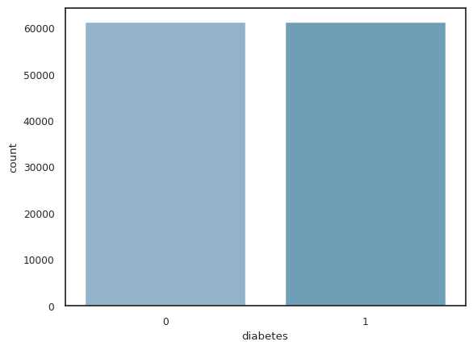

```python
# data split into training and testing using SMOTE
from imblearn.over_sampling import SMOTE
smote = SMOTE()
x_smote, y_smote = smote.fit_resample(X_train, y_train)

sns.countplot(x=y_smote)
```

Now, after oversampling using SMOTE, we have an equal number of positive and negative cases in the dataset.

```python
# Logestic Regression using SMOTE
GSLR_smt = GridSearchCV(model_lr, param_lr, cv=5, scoring='accuracy', n_jobs=-1)
best_clf_GSLR_smt = GSLR_smt.fit(x_smote, y_smote)
clf_performance(best_clf_GSLR_smt,'Logestic Regression with SMOTE')
```

```
Logestic Regression with SMOTE
Best Score: 0.8673066780748163
Best Parameters: {'C': 0.9, 'penalty': 'l1', 'tol': 0.0001}
```

```python
# Decsion Tree using SMOTE
GSDT_smt = GridSearchCV(model_dt, param_dt, cv=5, scoring='accuracy', n_jobs=-1)
best_clf_GSDT_smt = GSDT_smt.fit(x_smote, y_smote)
clf_performance(best_clf_GSDT_smt,'Logestic Regression with SMOTE')
```

```
Logestic Regression with SMOTE
Best Score: 0.9528785004500062
Best Parameters: {'criterion': 'entropy', 'max_depth': None, 'max_features': None, 'min_samples_leaf': 1, 'min_samples_split': 2}
```

```python
# Random Forest using SMOTE
GSRF_smt = GridSearchCV(model_rf, param_rf, cv=5, scoring='accuracy', n_jobs=-1)
best_clf_GSRF_smt = GSRF_smt.fit(x_smote, y_smote)
clf_performance(best_clf_GSRF_smt,'Random Forest with SMOTE')
```

```
Random Forest with SMOTE
Best Score: 0.9626337004617491
Best Parameters: {'criterion': 'entropy', 'max_depth': None, 'max_features': 'sqrt', 'min_samples_leaf': 1, 'min_samples_split': 2, 'n_estimators': 100}
```

```python
# KNN using SMOTE
GSKNN_smt = GridSearchCV(model_knn, param_knn, cv = 5, scoring='accuracy', n_jobs = -1)
best_clf_GSKNN_smt = GSKNN_smt.fit(x_smote, y_smote)
clf_performance(best_clf_GSKNN_smt,'KNN with SMOTE')
```

```
KNN with SMOTE
Best Score: 0.9515011892179037
Best Parameters: {'algorithm': 'ball_tree', 'n_neighbors': 3, 'p': 1, 'weights': 'distance'}
```

The Random Forest model has the highest accuracy score.

### Prediction

```
Model Accuracy:  0.9706994001178959
              precision    recall  f1-score   support

           0       0.97      1.00      0.98     26294
           1       1.00      0.67      0.80      2545

    accuracy                           0.97     28839
   macro avg       0.98      0.83      0.89     28839
weighted avg       0.97      0.97      0.97     28839
```

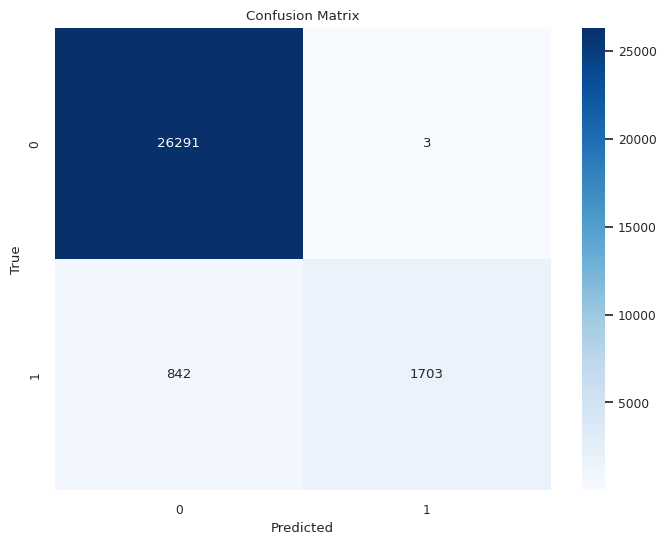

```python
# Predict on the test set using the best model
pred_rf = GSRF.predict(X_test)

# Evaluate the model
print("Model Accuracy: ", accuracy_score(y_test, pred_rf))
print(classification_report(y_test, pred_rf))

# Plot confusion matrix
cm = confusion_matrix(y_test, pred_rf)
plt.figure(figsize=(8, 6))
sns.heatmap(cm, annot=True, fmt='d', cmap='Blues')
plt.title('Confusion Matrix')
plt.xlabel('Predicted')
plt.ylabel('True')
plt.show()
```

## Conclusion

hroughout this project, we have conducted thorough research, extensive data exploration, and rigorous analysis of the variables to develop and evaluate a model for predicting the likelihood of developing diabetes. The Random Forest model, without the use of SMOTE, provided the best accuracy for predicting diabetes status. However, there is still potential for further enhancements and refinements to improve its performance.

Originally, this dataset presented a substantial imbalance in the values of diabetes, with a ratio of nearly 9:1. Consequently, I attempted two different sampling methods to improve prediction on the test set. While some models using SMOTE (like the Decision Tree and Random Forest) still had good prediction accuracies, the accuracy of logistic regression using the SMOTE method decreased significantly. Nevertheless, these accuracy levels were not higher than those achieved with the initial sampling method. The Decision Tree model, in particular, demonstrated a generally good prediction regardless of the sampling method. This illustrates that although SMOTE is a popular method used to address class imbalance in machine learning datasets, it might not always yield the best results. We must always be cautious of overfitting in such cases.

The accuracy for all models was higher than I initially expected. Despite the substantial imbalance in diabetes values, we achieved quite satisfactory results with our best-performing model, Random Forest, 0.9706994001178959 accuracy score.

Overall, it was interesting to explore the likelihood and correlation of different predictors with diabetes. This research provided valuable insights into the factors influencing this health condition and allowed us to devise an effective predictive model.

## Save as HTML

```python
!pip install nbconvert
```

```python
!jupyter nbconvert --to HTML Diabetes_prac2.ipynb
```

[output not shown]